# CODA TMSR Report

08 April, 2024

# The Current Study

This text mining systematic review considered the *frequency* with which a construct is covered in the literature, or *term frequency*, to be indicative of its relevance. Term frequency can be rank ordered to identify the most relevant constructs. Furthermore, the frequency with which constructs are investigated together within publications, or *co-occurrence*, is considered to be indicative of a putative relationship between them. These two metrics can be jointly visualized as a network, thereby “mapping” constructs relevant to cooperation.

# Methods

## Vector Embedding

Our analysis focused on nouns and adjectives, as these are (jointly) able to represent constructs. Nouns most commonly reference theoretically meaningful constructs; for example, the words “prisoner’s dilemma” will both be tagged as nouns. However, adjectives occasionally also capture meaningful constructs; for example, the words “competitive individuals” will be tagged as an adjective and a noun. In this case, the word “individuals” does not relate to a theoretically meaningful construct, but the adjective “competitive” does. We performed Part-Of-Speech (POS) tagging using the `stanza` pipeline to identify nouns and adjectives; henceforth referred to jointly as words. We obtained numerical representations for the words using the pretrained SciBERT language model. This model is finetuned on scientific text data, including studies of cooperation, and should thus provide high quality context-aware numerical representations. Moreover, SciBERT and other BERT models are able to handle words that did not occur in the training vocabulary, thus allowing a complete-data analysis. Each word was embedded using the rest of the sentence as context. Simply put: Each word is represented as a string of numbers, but the same word does not always have the same numeric representation. For example, the word “game” would be represented differently if it was preceded by “prisoner” versus “dictator”. As this method requires uniform input data, sentences were truncated to 512 words. During embedding, words are broken up into constituent parts (e.g., “non-compliance” returns separate embeddings for “non” and “compliance”). We averaged embeddings of subwords within words. This resulted in 122251 unique words, each represented by 768 numbers.

## Clustering

To cluster individual words into constructs, we used Hierarchical Density-Based Spatial Clustering of Applications with Noise (HDBSCAN). This density-based clustering algorithm can identify clusters of varying shapes and sizes, while treating datapoints far away from any cluster as noise. This is useful because we expect many words to be irrelevant, and only few are expected to represent theoretically relevant constructs. Importantly, HDBSCAN performs poorly with high-dimensional data. We therefore first used Uniform Manifold Approximation and Projection (UMAP) to reduce the original 768 dimensions to 10. UMAP is a dimension reduction algorithm, but unlike PCA, it is non-linear and balances the preservation of the global and local structure of the data, which has been shown to work well when clustering word vector embeddings (https://ieeexplore.ieee.org/abstract/document/9640285). We extracted 10 dimensions, which is relatively high and thus ensures that no important information is lost. We used cosine similarity as a distance metric, which is conventional when working with vector embeddings. Furthermore, we specified a relatively small number of 5 neighbor points, which means the solution focuses more on local structure than global structure (which makes sense here, as the clusters will consist of local neighbors), and we specified a very low minimum distance value of 0.001 to ensure that points that are close together remain very close together, which should aid subsequent clustering. Subsequently, we performed HDBSCAN on the 10-dimensional UMAP vectors. For HDBSCAN, we used Euclidean distance, with a minimum cluster size of 100 words and a relatively large value of 15 for the number of surrounding datapoints needed to consider something a cluster centroid. These values are relatively arbitrary, but their effect is that we will only obtain clusters of at least 100 words, and that clusters will be restricted to relatively dense areas.

HDBSCAN with minimum cluster size of 100 words found 388 clusters. Out of 122251 words, 33654 were classified as noise. The remaining words were distributed across clusters as follows:

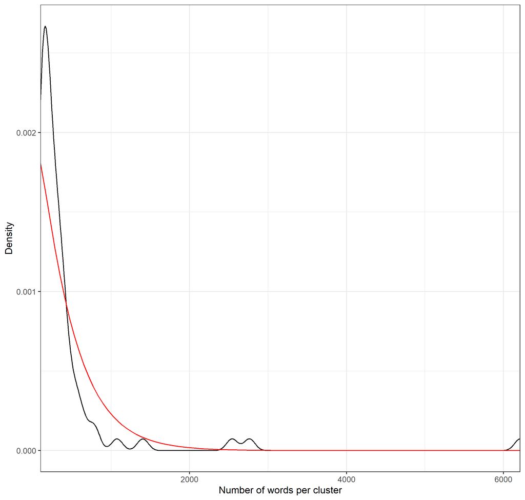

## Construct Frequency

This is the frequency of specific constructs:

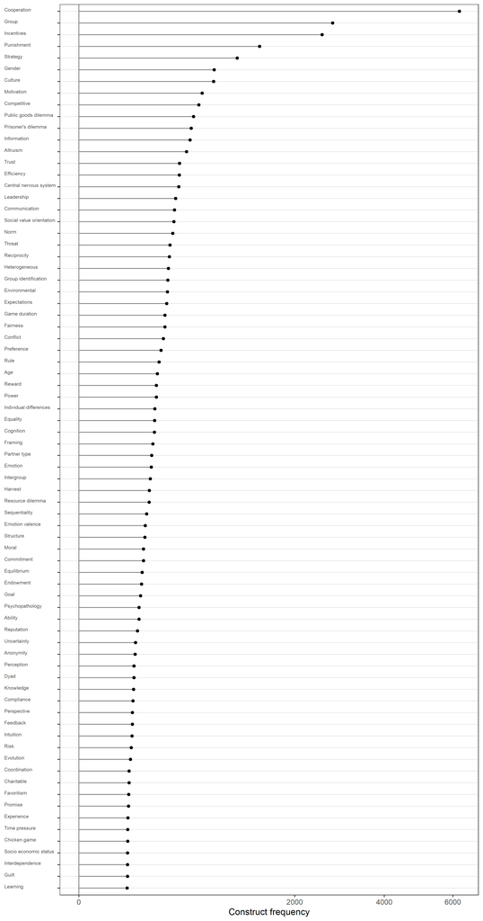

## Co-occurrence Graph

This graph illustrates which constructs co-occur within documents, with node size weighted by construct frequency and edge linesize weighted by the frequency of co-occurrence (logarithmically scaled).

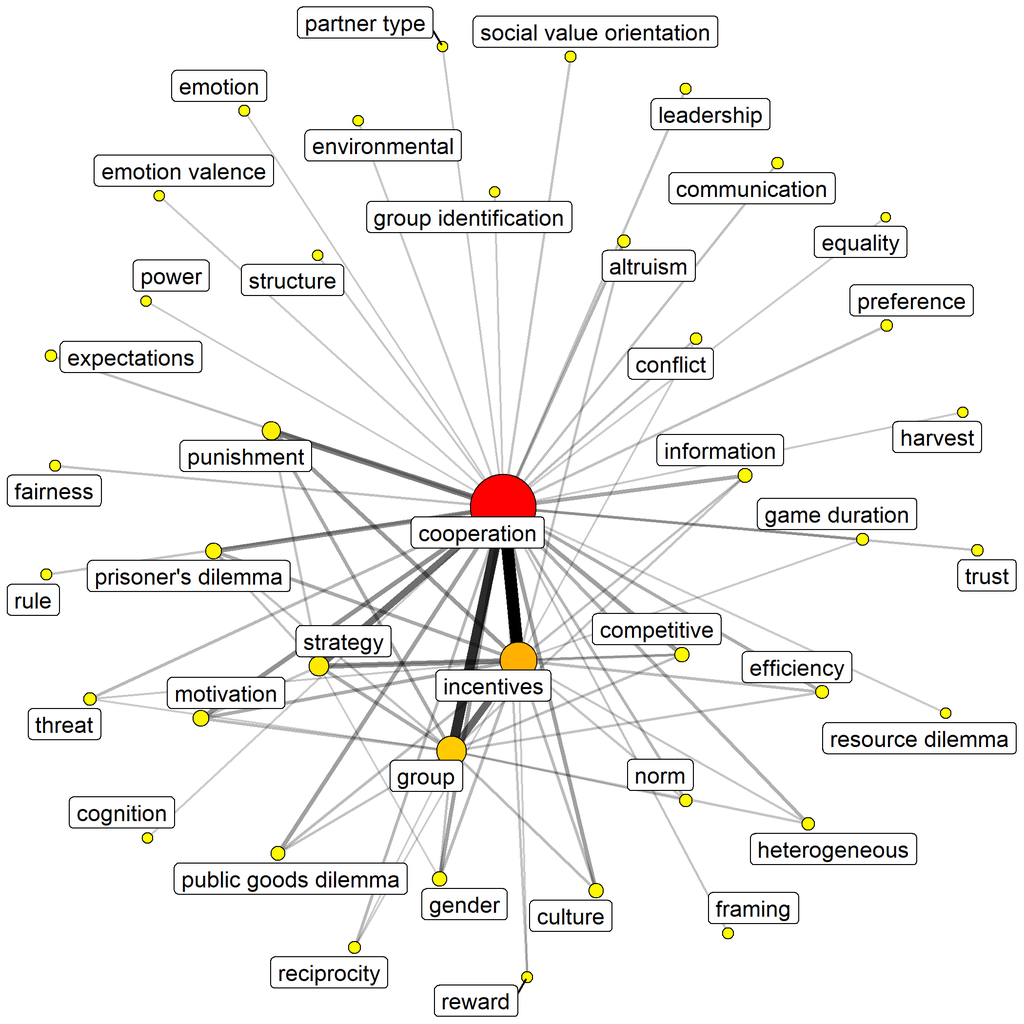

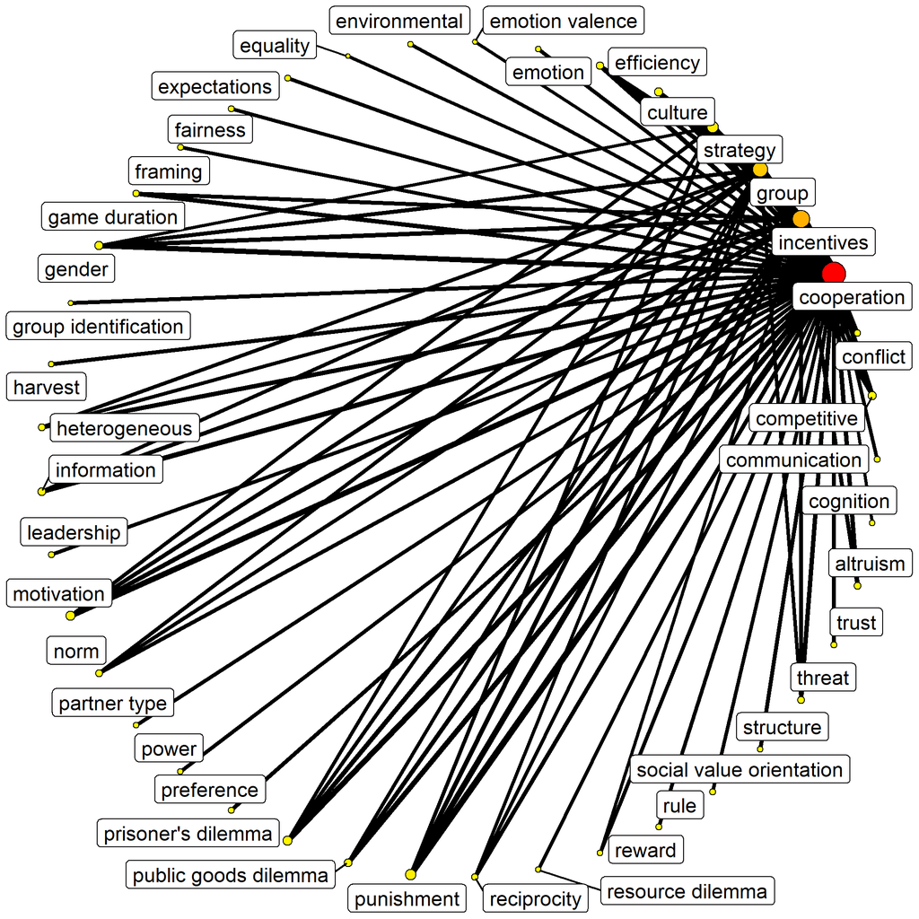

## Interactive Graph

[interactive chart not shown]

## Node Centrality

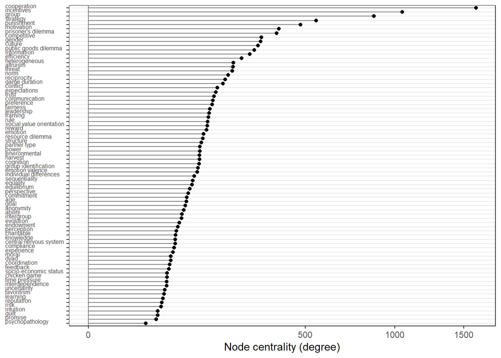

## Co-occurrence as List

This figure contains the same information as the network above, but as a list so it’s easier to see what the most common co-occurrence connections are:

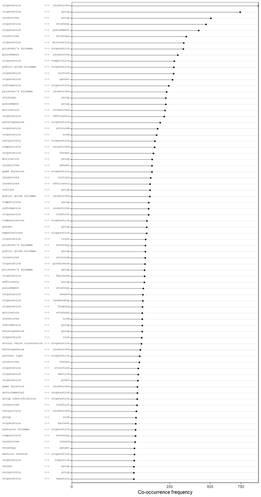

## Co-occurrence as List without Cooperation

This figure contains the same information as the list above, but all links involving cooperation have been dropped:

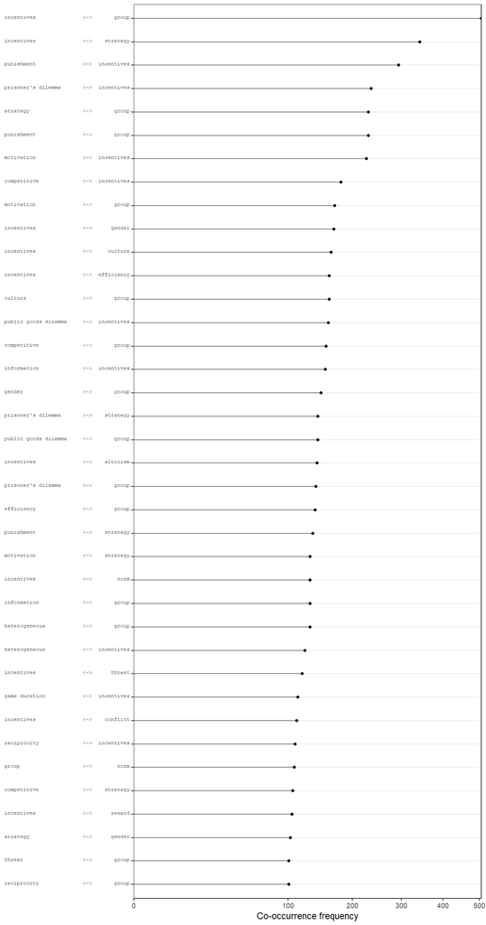

## Construct Details

[output not shown]

[output cut: 4222 more lines]

[output not shown]